# 4 — Making a Humanoid Walk

LIPM, ZMP, and an analytic gait · SOC4180 Robot and AI

Hong Jeong

## Today the robot walks

No reinforcement learning. No training. No neural network.

Everything today comes from **one linear differential equation** and the inverse kinematics you wrote in Week 3.

This is **Layer 4** — control and planning — doing the whole job on its own. When we replace parts of it with learning in Week 8 onward, this is what gets replaced, and you will know exactly what it was.

## Why walking is hard

Standing still is a solved problem: put the centre of mass over the feet.

Walking means **deliberately falling and catching yourself, twice a second.**

- A humanoid is **underactuated** — no motor connects the robot to the ground, so you cannot simply command the body where to go
- The only way to push the body is **through a foot that is touching the floor**
- To move forward you must first become unbalanced
- The support region *changes shape* every step, and briefly is one small foot

## The two ways to walk

**Static walking** keeps the centre of mass over the support foot at all times. The robot can freeze at any instant and stay upright. It is slow, and it looks like a robot from 1985.

**Dynamic walking** allows the centre of mass to leave the support region, relying on momentum to carry it to the next foothold. It is faster, more efficient, and how humans actually move — but freeze it mid-step and it falls.

We build the dynamic kind. The tool that makes it tractable is a model so simplified it seems like cheating.

## Centre of pressure, and the ZMP

The floor can only **push**, never pull. All the little contact forces under a foot sum to one resultant force, and the point where it acts is the **centre of pressure (CoP)**.

The CoP **cannot leave the support polygon** — the convex hull of the contact points. That is not a control law, it is geometry: there is no floor outside the foot to push with.

In walking this point is usually called the **Zero Moment Point (ZMP)**. The balance criterion for the whole semester:

> **ZMP inside the support polygon ⟹ the foot does not rotate about its edge.** Outside, the robot tips, and no ankle torque can stop it.

## Our support polygon

Each G1 foot has four contact spheres. Their spread *is* the polygon:

```
contact points in the foot frame (x, y):
[[-0.05   0.025]
 [-0.05  -0.025]
 [ 0.12   0.03 ]
 [ 0.12  -0.03 ]]

foot length 0.170 m, width 0.060 m
```

A single foot gives you about 17 cm by 6 cm to balance a 33 kg robot on. That is the entire margin.

## The polygon, drawn from the model

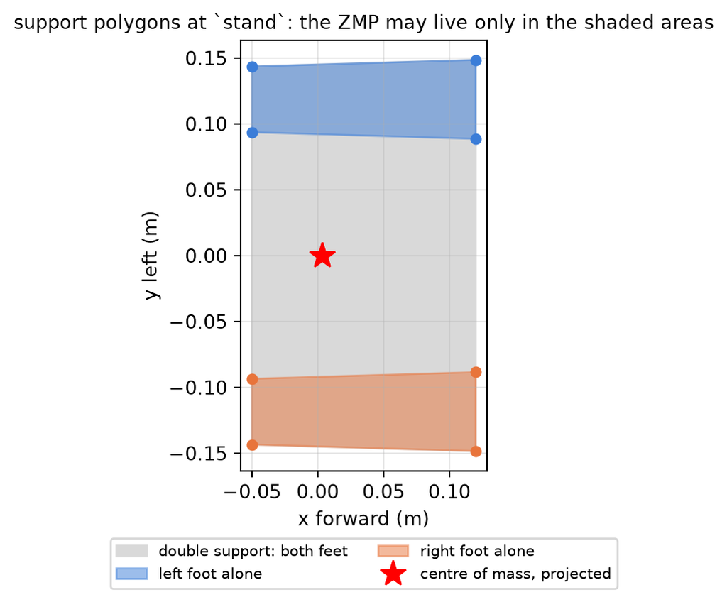

```
centre of mass projects to x = +0.003, y = +0.000
```

Standing on both feet the polygon is the big grey shape. Lift one foot and it collapses to a single 17 cm by 6 cm patch — and the centre of mass, the red star, has to be *above* it or the robot tips.

## The Linear Inverted Pendulum Model

Replace the robot with a point mass on a massless leg, and impose one assumption: **the centre of mass stays at constant height.**

That assumption removes the vertical dynamics and linearises everything:

$$\ddot{x} = \omega^2\,(x - p), \qquad \omega = \sqrt{g / z_c}$$

where $p$ is the ZMP. Read it as: **the mass accelerates away from the ZMP**, and faster the further away it gets. Balancing is unstable, which is why it needs constant attention.

$\omega$ is the only parameter, and $1/\omega$ is the natural timescale of falling.

## Where the equation comes from

Take moments about the ZMP. The floor pushes up through $p$; gravity pulls down through the mass. Hold the height at $z_c$ and the vertical acceleration is zero, so the floor force is exactly $mg$, and the moment balance is the whole equation of motion:

$$m\,z_c\,\ddot{x} \;=\; m\,g\,(x - p)
\qquad\Longrightarrow\qquad
\ddot{x} = \frac{g}{z_c}\,(x - p) = \omega^2 (x - p)$$

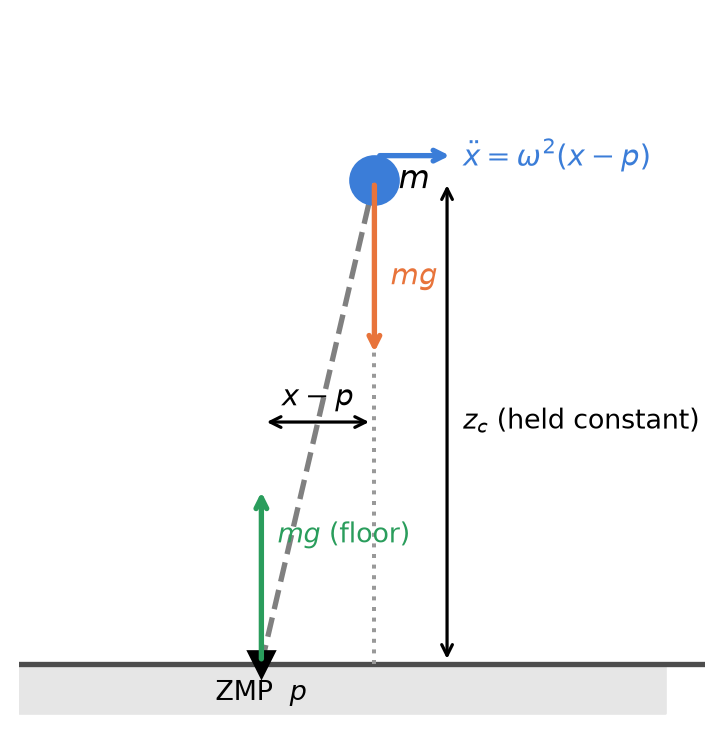

Every simplification is visible in the picture: one mass, a massless leg, a constant height, and a single point of support.

## Solving it exactly

The equation is linear with constant coefficients, so it has a closed-form solution — no integration, no optimisation:

$$x(t) = p + (x_0 - p)\cosh(\omega t) + \frac{v_0}{\omega}\sinh(\omega t)$$

```
omega   = 4.044 rad/s
1/omega = 0.247 s   <- how long you have to react
  t=0.0s  released 5 cm from the ZMP:  x=+0.0000 m  v=+0.0000 m/s
  t=0.1s  released 5 cm from the ZMP:  x=-0.0041 m  v=-0.0840 m/s
  t=0.2s  released 5 cm from the ZMP:  x=-0.0173 m  v=-0.1819 m/s
  t=0.4s  released 5 cm from the ZMP:  x=-0.0810 m  v=-0.4894 m/s
```

Released at rest, the mass runs away exponentially. `cosh` and `sinh` *are* falling over, written down.

## The trick: run it backwards

We do not want to know where the robot falls. We want to know **what launch velocity puts it where we need it** at the end of the step.

That is a two-point boundary value problem, and because the model is linear it also has a closed form:

$$v_0 = \omega\,\frac{x_T - p - (x_0 - p)\cosh(\omega T)}{\sinh(\omega T)}$$

```
required launch velocity : +0.3271 m/s
arrives at               : +0.0700 m  (asked for +0.0700)
with velocity            : +0.3271 m/s
```

**Each step is one boundary value problem.** Chain them — every step starting where the last ended — and you have a gait.

## The sideways problem

Forward motion is a straight line. Sideways is an oscillation, and it is the part that makes walking *look* like walking.

Demand that each step be the mirror of the last, $(y, v) \to (-y, -v)$. Working that through the step map forces $y_0 = 0$: **the centre of mass is always on the midline at the moment support switches.**

```
launch velocity toward the stance foot : +0.4164 m/s
maximum sway                           : 0.0594 m
stance foot is at                      : 0.1190 m
returns to midline at t=T              : +0.000000 m
```

The body sways **toward** the supporting foot, gravity turns it around, and it arrives back at the centre exactly when the other foot is ready. The sway is not decoration — it is what buys time to swing a leg.

## Both directions, drawn

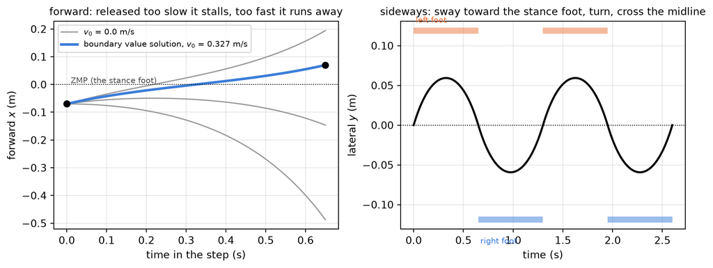

The left plot is $\cosh$ and $\sinh$ doing exactly what the equation says: the mass accelerates *away* from the ZMP, and there is one launch velocity that lands it where the next step needs it. The right plot never reaches the foot it leans toward — gravity turns it back — and crosses the midline exactly at each support exchange.

## Planning the footsteps

```
step length 0.14 m, step time 0.65 s, clearance 0.1 m
double support 20% at each end of the step

  step 0: stand on right at x=+0.00  swing +0.00 -> +0.07
  step 1: stand on left  at x=+0.07  swing +0.00 -> +0.14
  step 2: stand on right at x=+0.14  swing +0.07 -> +0.21
  step 3: stand on left  at x=+0.21  swing +0.14 -> +0.28
  step 4: stand on right at x=+0.28  swing +0.21 -> +0.35
```

The first step is a half stride, because both feet start level and a full stride would over-reach.

## Swinging the leg

The swing foot needs a path that **starts and ends at rest**. A foot still moving when it lands will slip or trip, and a foot that leaves abruptly drags.

- Horizontal: a cycloid-like blend, zero velocity at both ends
- Vertical: lift and lower, peaking at mid-swing
- **Double support**: for the first and last 20% of the step, *both* feet stay planted so weight can transfer

That double-support margin is not a detail. Without it the robot is on one foot 100% of the time and falls within a few steps — you will test this.

## The plan and the swing, drawn

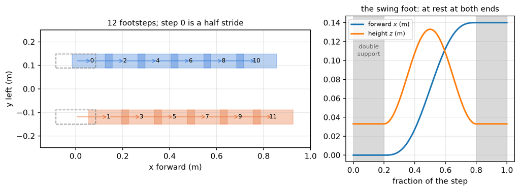

Feet alternate, each landing one stride ahead of where the same foot last stood. The swing curves have **zero slope at both ends** — the foot leaves and lands without a jolt — and go nowhere at all in the grey double-support bands.

## Assembling the controller

Every control cycle, at 500 Hz:

1. Which step are we in, and how far through it?
2. **Where should the body be?** → the LIPM boundary value problem
3. **Where should each foot be?** → planted, or on its swing path
4. **What joint angles achieve that?** → inverse kinematics, both legs
5. Send those angles to the position servos

Steps 2–3 are this week. Step 4 is Week 3’s work, reused unchanged. That is the payoff of building the layers separately.

## One trap: the singularity

The G1’s `stand` keyframe has **every leg joint at exactly zero** — a perfectly straight leg. That is a kinematic singularity: the Jacobian has no direction that shortens the leg, so IK cannot lower the body from it, at all.

```
'stand' left-leg joint angles: [0. 0. 0. 0. 0. 0.]
nominal crouch used instead   : [-0.35  0.    0.    0.7  -0.35  0.  ]
```

Every gait therefore starts from a **crouch**. Humans do this too: you do not walk with locked knees.

## Watch it walk

```
walked +0.99 m in 8.8 s (0.11 m/s), pelvis still at 0.72 m
```

## What you just watched

A 29-degree-of-freedom humanoid walking, driven by:

- one second-order linear ODE
- a closed-form solution to a boundary value problem, once per step
- a cycloid
- inverse kinematics

**No training. No data. No reward function.** Roughly two hundred lines.

Remember this when a walking policy takes 150 million simulation steps to learn the same thing. Learning buys robustness, not the gait itself.

## Now measure it

Belief is not evidence. Where did the ZMP actually go?

```
travelled     +0.989 m
pelvis height [0.693, 0.740] m — never fell
ZMP y range   [-0.233, +0.105] m
stance feet at +-0.119 m
```

## The model is wrong, usefully

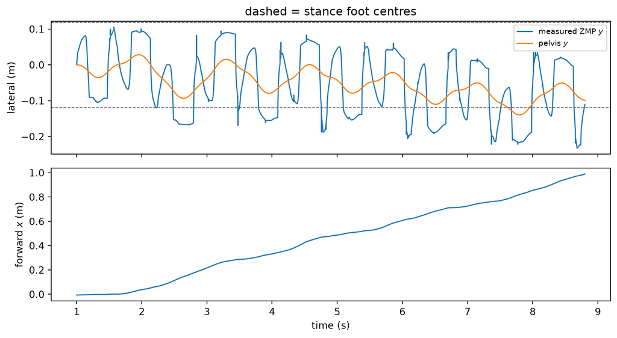

## Where the ZMP actually went

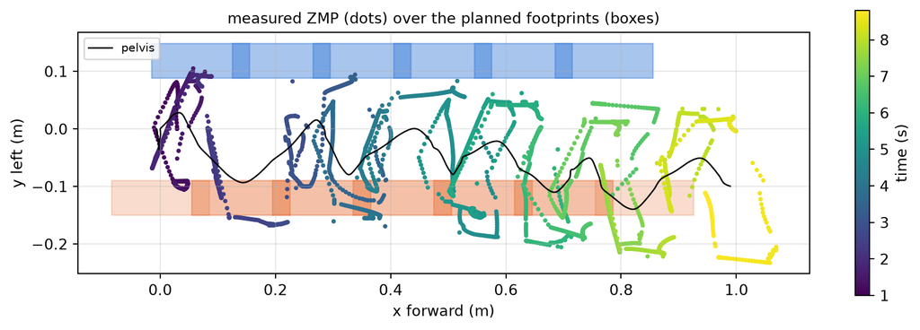

The dots should never leave a box. They do — by up to ten centimetres sideways at every support exchange. That is not a measurement error; it is the list on the next slide.

## Where the LIPM breaks

The measured ZMP swings **wider than the feet**. The theory says that cannot happen — and the theory is right; the assumptions are what failed:

| LIPM assumes | The G1 actually |
| --- | --- |
| A point mass | Has a swinging leg with real momentum |
| Constant CoM height | Bobs as the stance leg compresses |
| Massless legs | Carries ~30% of its mass below the hips |
| Instant support exchange | Rolls weight across a finite foot |
| Perfectly rigid position control | Uses servos of finite stiffness that sag |

It walks anyway. **A model does not have to be true to be useful — it has to be wrong in ways that do not matter yet.** Week 13 is where they start to matter.

## The honest limitations

This controller is **open loop**. It never looks at the IMU, never measures where the body actually is, and never corrects.

Consequences you can see in the data:

- it **drifts sideways** over many steps, with nothing to pull it back
- it cannot recover from a push, at all
- it walks on flat ground only — one unexpected step and it is over
- the gait is fixed at design time; asking for a different speed means re-deriving

Every one of these is a reason the field moved to learned policies. **Not because the mathematics is wrong** — you just watched it work — but because hand-derived control is brittle outside the conditions it was derived for.

## Lab class: on your laptop

```bash
uv run weeks/04-walking/lab_walk.py
```

The walker, live. `1`–`5` pick a gait from `GAITS`; `G` is the Moon and `F` ice, *without telling the controller*; ctrl-drag pushes. On the floor: the footstep plan (grey), the commanded CoM (white dots), `predict_com`’s CoM (blue dots), the pelvis (red), the measured ZMP (yellow). The code is complete and explained: `predict_com` is the LIPM by hand, `Walk` the loop around the controller.

| Step | Do | Right looks like |
| --- | --- | --- |
| 1 | `ENTER`; flip the sinh sign | gap 0.0, blue inside white; then the blue dots run backwards |
| 2 | `2` (no double support) | a fall at 2.0 s; which way, and why |
| 3 | `3` (rushed) | four steps then a fall at 3.2 s; 0.45 s against 1/ω = 0.247 s |
| 4 | `G` | the prediction from ω = √(g/z_c) first; six steps, a fall at 5.3 s |
| 5 | ctrl-drag while walking | it never reacts: what it would need to know |
| 6 | a gait that walks further than 0.99 m | `ENTER` proves it |

## Lab class: `walk.py`, plan → LIPM → IK → physics

```bash
uv run weeks/04-walking/walk.py --step-time 0.45
uv run weeks/04-walking/walk.py --double-support 0 --no-viewer
uv run weeks/04-walking/walk.py --gravity 1.62
```

Every gait parameter a flag; the plan and the pendulum printed; one row per step; a summary; then the replay with the plan, pelvis and ZMP on the floor.

```
pendulum: z_c = 0.6 m, omega = sqrt(g/z_c) = 4.04 rad/s, 1/omega = 0.247 s (the step is 2.6 time constants long)
LIPM by hand vs soc4180.LIPM over the first step: max difference 0.0e+00 m
step  t (s)   x (m)  pelvis z    ZMP y range (m)  IK err (m)
   1   1.65  +0.001     0.715 [-0.105, +0.105]     9.3e-07
   2   2.30  +0.072     0.716 [-0.120, +0.100]     9.8e-07
  ...
walked +0.989 m in 8.80 s; pelvis ends at 0.716 m; upright
measured ZMP y swung over [-0.233, +0.105] m against stance feet at +-0.119 m: OUTSIDE the support polygon
```

| Step | Does | Calls |
| --- | --- | --- |
| 1 | robot, world, gait, plan | `opt.gravity`, `geom_friction`, `GaitParams`, `WalkingController` |
| 2 | LIPM by hand vs package | `_segments`, `lipm.evolve` |
| 3 | the loop, a row per step | `control(t)`, `mj_step`, `zmp(data)`, `last_ik_error` |
| 6 | replay with markers | `launch_viewer(passive=True)`, `user_scn` |

## Exercises

Break it deliberately, and record what fails and why.

1. **Remove double support.** Set `double_support=0.0`. How many steps before it falls? Which direction, and why that direction?
2. **Rush it.** Reduce `step_time` toward 0.35 s. Find the value where it fails. Compare it to $1/\omega$ — is the failure point near the model’s own timescale?
3. **Overstride.** Increase `step_length`. Where does it break, and is it the swing leg reaching its limit or the balance failing?
4. **Ice.** Set the floor friction to 0.2 (`model.geom_friction[0, 0] = 0.2`). The ZMP argument assumes no slipping — what actually happens?
5. **Moon.** Set gravity to $-1.62\ \mathrm{m/s^2}$ **without** changing the controller. Predict the failure from $\omega = \sqrt{g/z_c}$ before running it.
6. **Instrument it.** Plot the ZMP against the *support polygon of the current stance foot* rather than a fixed line, and measure what fraction of the walk is genuinely inside.

## Next week

**05 — actuation and PD control.** Today we assumed the joints simply go where they are told. They do not: they are position servos with finite gain, and that is why the pelvis sagged below its commanded height all through this lecture.

We tune those gains, measure tracking error against torque saturation, and then build a gait with **no model at all** — a central pattern generator — to compare against today’s.